# DATA 607 Week9 Assignment - Working with Web APIs in R

Soumya Ghosh

October 27, 2018

### Assignment Summary:

Below is the summary of the assignment -

[figure not shown]

### GitHub Location:

https://github.com/soumya2g/R-CUNY-MSDS/tree/master/DATA-607/JSON%20Web%20API

### R Libraries:

Load necessary libraries -

```r
library(kableExtra)
library(rvest)
library(httr)
library(jsonlite)
library(data.table)
```

### Assignment Goal :

##### **Purpose**: This R Code is written like an Interface program which will receive the API URL and the API Key.

##### The JSON response received by the API Call will be flattened and transformed into a R data frame.

##### **Note:** New York Time API Development site has been used as an example here. But this interface program

##### is generic and can be used for any API based Web data source with a JSON response.

Below are the steps to be followed to generate the final output -

1. I have registered in the New York Time Developer Web site (http://developer.nytimes.com/) and got below API Key -

```r
API_Key = "31b8d9353fbb4fbdb9c1d4d9c32dd991"
```

2. I have picked following API to test the output of the R Function:

### API screenshot:

[figure not shown]

3. Below is a quick snapshot of the required API parameters for the chosen API and the nested JSON structure of a successful response denoted by response code 200 from the New Yprk Times API server -

### API Parameter Request and Response Structure :

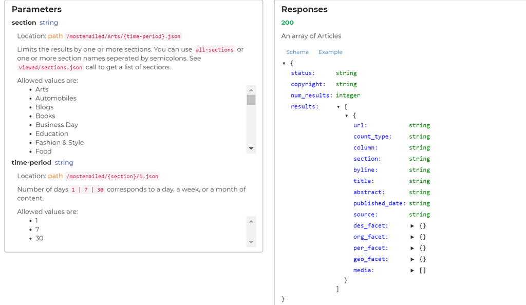

### API URL:

For the purpose of demonstrating the functianlity of this R API Interface program, I have chosen **‘all-sections’** as a section and **‘1’** as the no. of days. So the resultant API URL will looks like below -

```r
url <- "https://api.nytimes.com/svc/mostpopular/v2/mostemailed/all-sections/1.json"
```

### R Interface Funtion :

I have created a R function called **‘GetAPIResponse’** which will require the API URL and the API Key as the input and it will return the Flat R Data Frame containing the API’s JSON response data.

```r
GetAPIResponse <- function(API_URL,API_Key)
{
  ## Calculate the total page count since the source only provides 20 results per page
  initialResponse <- GET(API_URL, add_headers('api-key'=API_Key))
  initialContent <- content(initialResponse,"text")

  initialQuery <- fromJSON(initialContent)
  maxPages <- round((initialQuery$num_results/ 20)-1)

  ## Query the source based on the page count and append to a list of data frames
  pages <- list()
  for(i in 0:maxPages){
    apiResponse <- GET(API_URL, add_headers('api-key'=API_Key,'page'=i))
    responseContent <- content(apiResponse,"text")

    raw_df <- as.data.frame(fromJSON(responseContent, simplifyDataFrame = T, flatten = T), stringsAsFactors = FALSE)
    pages[[i+1]] <- raw_df
    Sys.sleep(1)
  }

  ## Merge the list of data frames into one data frame
  allPagesDF <- rbind_pages(pages)

  str(allPagesDF)


# One way to "flatten" the API's JSON response is to "fix" the list columns. There are three possible fixes -
#
# 1. flatten function (from "jsonlite") will take care of columns with type data frame .
# 2. Columns of type list can be fixed using toString, which would convert each element to a comma separated item or which can be converted into multiple columns.
# 3. Columns where there are data.frames, some with multiple rows, first need to be flattened into a single row (by transforming to a "wide" format) and then need to be bound together as a single data.table.(I'm using "data.table" for reshaping and for binding the rows together).

  columnFixer <- function(x, vec2col = FALSE)
  {
    if (!is.list(x[[1]])) {
      if (isTRUE(vec2col)) {
        as.data.table(data.table::transpose(x))
      } else {
        vapply(x, toString, character(1L))
      }
    } else {
      temp <- rbindlist(x, use.names = TRUE, fill = TRUE, idcol = TRUE)
      temp[, .time := sequence(.N), by = .id]
      value_vars <- setdiff(names(temp), c(".id", ".time"))
      dcast(temp, .id ~ .time, value.var = value_vars)[, .id := NULL]
    }
  }

#  We can take care of the second and third points with a function like the following:

  Flattener <- function(input_df, vec2col = FALSE) {
    input_df <- flatten(input_df)
    listColumns <- sapply(input_df, is.list)
    newCols <- do.call(cbind, lapply(input_df[listColumns], columnFixer, vec2col))
    input_df[listColumns] <- list(NULL)
    cbind(input_df, newCols)
  }


  ### 1st Flattenr() Function Call

  final_df <- Flattener(allPagesDF,vec2col = FALSE)

  ### Check if there is any other nested List or Data Frame columns

  listColumnsVec <- sapply(final_df, is.list)

  ### Recursively call the Flattenr() function until the resultset is completely flattened

  while(!is.na(table(listColumnsVec)["TRUE"]))
  {
    final_df <- Flattener(final_df,vec2col = FALSE)
    listColumnsVec <- sapply(final_df, is.list)
  }

  ## Return the resultset
  return(final_df)

}
```

### Calling R API Interface Function:

```r
### API Response Function call

responseDF <- GetAPIResponse (url,API_Key)
```

[output not shown]

[output cut: 1552 more lines]

[output not shown]

```r
#### Final result Data Frame

responseDF %>% kable() %>% kable_styling(bootstrap_options = c("striped", "hover", "condensed", "responsive")) %>% scroll_box(width="100%",height="400px")
```

| status | copyright | num_results | results.url | results.count_type | results.column | results.section | results.byline | results.title | results.abstract | results.published_date | results.source | results.des_facet | results.org_facet | results.per_facet | results.geo_facet | results.media.type_1 | results.media.subtype_1 | results.media.caption_1 | results.media.copyright_1 | results.media.approved_for_syndication_1 | results.media.media-metadata_1.url_1 | results.media.media-metadata_1.url_2 | results.media.media-metadata_1.url_3 | results.media.media-metadata_1.format_1 | results.media.media-metadata_1.format_2 | results.media.media-metadata_1.format_3 | results.media.media-metadata_1.height_1 | results.media.media-metadata_1.height_2 | results.media.media-metadata_1.height_3 | … |
| --- | --- | --- | --- | --- | --- | --- | --- | --- | --- | --- | --- | --- | --- | --- | --- | --- | --- | --- | --- | --- | --- | --- | --- | --- | --- | --- | --- | --- | --- | --- |
| OK | Copyright (c) 2018 The New York Times Company. All Rights Reserved. | 544 | https://www.nytimes.com/2018/10/26/style/phones-children-silicon-valley.html | EMAILED | NA | Style | By NELLIE BOWLES | A Dark Consensus About Screens and Kids Begins to Emerge in Silicon Valley | “I am convinced the devil lives in our phones.” | 2018-10-26 | The New York Times | COMPUTERS AND THE INTERNET, CHILDREN AND CHILDHOOD |  |  | SILICON VALLEY (CALIF) | image | photo |  | Photo Illustration by Tracy Ma/The New York Times; Getty Images (woman and child) | 1 | https://static01.nyt.com/images/2018/10/28/fashion/26NoTech-1/XX-screens-1-thumbStandard.jpg | https://static01.nyt.com/images/2018/10/28/fashion/26NoTech-1/26NoTech-1-mediumThreeByTwo210-v2.jpg | https://static01.nyt.com/images/2018/10/28/fashion/26NoTech-1/26NoTech-1-mediumThreeByTwo440-v2.jpg | Standard Thumbnail | mediumThreeByTwo210 | mediumThreeByTwo440 | 75 | 140 | 293 | … |
| OK | Copyright (c) 2018 The New York Times Company. All Rights Reserved. | 544 | https://www.nytimes.com/2018/10/26/opinion/sunday/phonics-teaching-reading-wrong-way.html | EMAILED | NA | Opinion | By EMILY HANFORD | Why Are We Still Teaching Reading the Wrong Way? | Teacher preparation programs continue to ignore the sound science behind how people become readers. | 2018-10-26 | The New York Times | READING AND WRITING SKILLS (EDUCATION), EDUCATION (K-12), TEACHERS AND SCHOOL EMPLOYEES | ILLITERACY, LANGUAGE AND LANGUAGES, NATIONAL COUNCIL ON TEACHER QUALITY |  |  | image | photo |  | Boyoun Kim | 1 | https://static01.nyt.com/images/2018/10/28/opinion/sunday/28hanford/28hanford-thumbStandard.jpg | https://static01.nyt.com/images/2018/10/28/opinion/sunday/28hanford/28hanford-mediumThreeByTwo210.jpg | https://static01.nyt.com/images/2018/10/28/opinion/sunday/28hanford/28hanford-mediumThreeByTwo440.jpg | Standard Thumbnail | mediumThreeByTwo210 | mediumThreeByTwo440 | 75 | 140 | 293 | … |
| OK | Copyright (c) 2018 The New York Times Company. All Rights Reserved. | 544 | https://www.nytimes.com/2018/10/27/style/cbd-benefits.html | EMAILED | NA | Style | By ALEX WILLIAMS | Why Is CBD Everywhere? | Cannabidiol is being touted as a magical elixir, a cure-all now available in bath bombs, dog treats and even pharmaceuticals. But maybe its just a fix for our anxious times. | 2018-10-27 | The New York Times | MARIJUANA, ANXIETY AND STRESS, YOUR-FEED-SELFCARE | CANNABIS FOODS AND PRODUCTS, ALTERNATIVE AND COMPLEMENTARY MEDICINE |  |  | image | photo |  | Photo Illustration by Eric Helgas for The New York Times | 1 | https://static01.nyt.com/images/2018/10/28/fashion/28CBD2/28CBD2-thumbStandard.jpg | https://static01.nyt.com/images/2018/10/28/fashion/28CBD2/28CBD2-mediumThreeByTwo210-v2.jpg | https://static01.nyt.com/images/2018/10/28/fashion/28CBD2/28CBD2-mediumThreeByTwo440-v2.jpg | Standard Thumbnail | mediumThreeByTwo210 | mediumThreeByTwo440 | 75 | 140 | 293 | … |
| OK | Copyright (c) 2018 The New York Times Company. All Rights Reserved. | 544 | https://www.nytimes.com/2018/10/26/style/digital-divide-screens-schools.html | EMAILED | NA | Style | By NELLIE BOWLES | The Digital Gap Between Rich and Poor Kids Is Not What We Expected | Americas public schools are still promoting devices with screens  even offering digital-only preschools. The rich are banning screens from class altogether. | 2018-10-26 | The New York Times | EDUCATION (K-12), INCOME INEQUALITY, COMPUTERS AND THE INTERNET, CHILDREN AND CHILDHOOD | PARENTING |  |  | image | photo |  | Photo Illustration by Tracy Ma/The New York Times; Getty Images (student) | 1 | https://static01.nyt.com/images/2018/10/26/style/26DigitalDivide-PROMO/26DigitalDivide-PROMO-thumbStandard.jpg | https://static01.nyt.com/images/2018/10/26/style/26DigitalDivide-PROMO/26DigitalDivide-PROMO-mediumThreeByTwo210.jpg | https://static01.nyt.com/images/2018/10/26/style/26DigitalDivide-PROMO/26DigitalDivide-PROMO-mediumThreeByTwo440.jpg | Standard Thumbnail | mediumThreeByTwo210 | mediumThreeByTwo440 | 75 | 140 | 293 | … |
| OK | Copyright (c) 2018 The New York Times Company. All Rights Reserved. | 544 | https://www.nytimes.com/2018/10/26/style/silicon-valley-nannies.html | EMAILED | NA | Style | By NELLIE BOWLES | Silicon Valley Nannies Are Phone Police for Kids | Child care contracts now demand that nannies hide phones, tablets, computers and TVs from their charges. | 2018-10-26 | The New York Times | CHILD CARE, PARENTING, YOUR-FEED-SELFCARE, COMPUTERS AND THE INTERNET | SOCIAL MEDIA |  | SAN FRANCISCO BAY AREA (CALIF) | image | photo |  | Photo Illustration by Tracy Ma/The New York Times; Shutterstock (child and phone) | 1 | https://static01.nyt.com/images/2018/10/26/style/26SiliconNannies-1/26SiliconNannies-thumbStandard.jpg | https://static01.nyt.com/images/2018/10/26/style/26SiliconNannies-1/26SiliconNannies-mediumThreeByTwo210.jpg | https://static01.nyt.com/images/2018/10/26/style/26SiliconNannies-1/26SiliconNannies-mediumThreeByTwo440.jpg | Standard Thumbnail | mediumThreeByTwo210 | mediumThreeByTwo440 | 75 | 140 | 293 | … |
| OK | Copyright (c) 2018 The New York Times Company. All Rights Reserved. | 544 | https://www.nytimes.com/2018/10/27/opinion/synagogue-shooting-pittsburgh.html | EMAILED | NA | Opinion | By BARI WEISS | A Massacre in the Heart of Mr. Rogers Neighborhood | Squirrel Hill will continue to live by the values that Jews have sustained for more than 2,000 years. They can never be gunned down. | 2018-10-27 | The New York Times | PITTSBURGH, PA, SHOOTING (2018), JEWS AND JUDAISM, SYNAGOGUES | TREE OF LIFE (PITTSBURGH, PA, SYNAGOGUE), IMMIGRATION AND EMIGRATION, ANTI-SEMITISM, HEBREW IMMIGRANT AID SOCIETY, ANTI-DEFAMATION LEAGUE | BOWERS, ROBERT D (1972- ) | PITTSBURGH (PA) | image | photo | People gathered for a vigil in the aftermath of a deadly shooting in the Squirrel Hill neighborhood of Pittsburgh. | Matt Rourke/Associated Press | 1 | https://static01.nyt.com/images/2018/10/29/opinion/27weissWeb/27weissWeb-thumbStandard.jpg | https://static01.nyt.com/images/2018/10/29/opinion/27weissWeb/27weissWeb-mediumThreeByTwo210.jpg | https://static01.nyt.com/images/2018/10/29/opinion/27weissWeb/27weissWeb-mediumThreeByTwo440.jpg | Standard Thumbnail | mediumThreeByTwo210 | mediumThreeByTwo440 | 75 | 140 | 293 | … |
| OK | Copyright (c) 2018 The New York Times Company. All Rights Reserved. | 544 | https://www.nytimes.com/2018/10/27/opinion/sunday/donald-trump-fear.html | EMAILED | Op-Ed Columnist | Opinion | By MAUREEN DOWD | ‘Riling Up the Crazies’ | The only thing we have to fear is Trump himself. | 2018-10-27 | The New York Times | UNITED STATES POLITICS AND GOVERNMENT | FOX NEWS CHANNEL, PROPAGANDA, REPUBLICAN PARTY | AILES, ROGER E, SAYOC, CESAR A (1962- ), TRUMP, DONALD J |  | image | photo | TV news coverage is reflected in the portrait of President Trump, showing the mail bomb suspect Cesar Sayoc Jr., at the Department of Justice in Washington on Friday. | Shawn Thew/Epa-Efe, via Rex | 0 | https://static01.nyt.com/images/2018/10/28/opinion/28dowd/28dowd-thumbStandard.jpg | https://static01.nyt.com/images/2018/10/28/opinion/28dowd/merlin_145890351_02661038-e4db-488c-8a84-0528fa9e7e7c-mediumThreeByTwo210.jpg | https://static01.nyt.com/images/2018/10/28/opinion/28dowd/merlin_145890351_02661038-e4db-488c-8a84-0528fa9e7e7c-mediumThreeByTwo440.jpg | Standard Thumbnail | mediumThreeByTwo210 | mediumThreeByTwo440 | 75 | 140 | 293 | … |
| OK | Copyright (c) 2018 The New York Times Company. All Rights Reserved. | 544 | https://www.nytimes.com/2018/10/27/opinion/sugar-land-texas-graves-slavery.html | EMAILED | Editorial Observer | Opinion | By BRENT STAPLES | A Fate Worse Than Slavery, Unearthed in Sugar Land | Bodies of sugar cane workers recently discovered in Texas reveal gruesome details about the convict leasing system. | 2018-10-27 | The New York Times | SLAVERY (HISTORICAL), SUGAR, BLACKS, FORCED LABOR | TEXAS MONTHLY | DOUGLASS, FREDERICK | SUGAR LAND (TEX), TEXAS, FORT BEND COUNTY (TEX) | image | photo | The Imperial Prison Farm Cemetery has 31 marked graves of inmates and guards dating 1912-1943. | Ilana Panich-Linsman for The New York Times | 1 | https://static01.nyt.com/images/2018/10/28/opinion/25sugar-edt/25sugar-edt-thumbStandard.jpg | https://static01.nyt.com/images/2018/10/28/opinion/25sugar-edt/merlin_145359597_df85bfa6-f507-4d41-969b-fb440eec89bc-mediumThreeByTwo210.jpg | https://static01.nyt.com/images/2018/10/28/opinion/25sugar-edt/merlin_145359597_df85bfa6-f507-4d41-969b-fb440eec89bc-mediumThreeByTwo440.jpg | Standard Thumbnail | mediumThreeByTwo210 | mediumThreeByTwo440 | 75 | 140 | 293 | … |
| OK | Copyright (c) 2018 The New York Times Company. All Rights Reserved. | 544 | https://www.nytimes.com/2018/10/26/opinion/coetzee-novel-waiting-barbarians.html | EMAILED | NA | Opinion | By ROGER COHEN | The Barbarians Are Within | America is a self-governing enterprise. In the face of feckless and corrupt people, there are better options. | 2018-10-26 | The New York Times | BOOKS AND LITERATURE |  | COETZEE, J M, TRUMP, DONALD J |  | image | photo |  | Tom Brenner for The New York Times | 1 | https://static01.nyt.com/images/2018/10/26/opinion/26cohenWeb/26cohenWeb-thumbStandard.jpg | https://static01.nyt.com/images/2018/10/26/opinion/26cohenWeb/26cohenWeb-mediumThreeByTwo210.jpg | https://static01.nyt.com/images/2018/10/26/opinion/26cohenWeb/26cohenWeb-mediumThreeByTwo440.jpg | Standard Thumbnail | mediumThreeByTwo210 | mediumThreeByTwo440 | 75 | 140 | 293 | … |
| OK | Copyright (c) 2018 The New York Times Company. All Rights Reserved. | 544 | https://www.nytimes.com/2018/10/27/opinion/are-the-danes-melancholy-are-the-swedes-sad.html | EMAILED | NA | Opinion | By PAUL KRUGMAN | Are the Danes Melancholy? Are the Swedes Sad? | The truth about the Nordic economies. | 2018-10-27 | The New York Times | INCOME INEQUALITY, WORK-LIFE BALANCE | GROSS DOMESTIC PRODUCT, LIS, WHITE HOUSE COUNCIL OF ECONOMIC ADVISERS |  | DENMARK, FINLAND, NORDIC COUNTRIES, SWEDEN | image | photo | A Denmark soccer fan during the 2018 World Cup. Studies show Danes have a high level of “life satisfaction.” | Kai Pfaffenbach/Reuters | 1 | https://static01.nyt.com/images/2018/10/27/opinion/27krugman/merlin_140310747_85f06544-3d03-422b-b265-1442da8a5c7d-thumbStandard.jpg | https://static01.nyt.com/images/2018/10/27/opinion/27krugman/merlin_140310747_85f06544-3d03-422b-b265-1442da8a5c7d-mediumThreeByTwo210.jpg | https://static01.nyt.com/images/2018/10/27/opinion/27krugman/merlin_140310747_85f06544-3d03-422b-b265-1442da8a5c7d-mediumThreeByTwo440.jpg | Standard Thumbnail | mediumThreeByTwo210 | mediumThreeByTwo440 | 75 | 140 | 293 | … |
| OK | Copyright (c) 2018 The New York Times Company. All Rights Reserved. | 544 | https://www.nytimes.com/2018/10/26/opinion/colorado-midterms-election-purple-state.html | EMAILED | NA | Opinion | By ROGER COHEN | Can Colorado Save America? | Its impossible to drive across the state and not be reminded of the first boundlessness of American potential. | 2018-10-26 | The New York Times | POLITICS AND GOVERNMENT, UNITED STATES POLITICS AND GOVERNMENT, MIDTERM ELECTIONS (2018) | ELECTIONS, GOVERNORS | HICKENLOOPER, JOHN W, POLIS, JARED S (1975- ), SALAZAR, KEN | COLORADO | image | photo | Glenna Nix outside her home in Nucla, Colo. Her daughter, who cared for two of her own daughters and had extraordinary expenses for seizure medication, recently committed suicide. | Daniel Brenner for The New York Times | 1 | https://static01.nyt.com/images/2018/10/28/opinion/28cohen-01/28cohen-01-thumbStandard.jpg | https://static01.nyt.com/images/2018/10/28/opinion/28cohen-01/28cohen-01-mediumThreeByTwo210.jpg | https://static01.nyt.com/images/2018/10/28/opinion/28cohen-01/28cohen-01-mediumThreeByTwo440.jpg | Standard Thumbnail | mediumThreeByTwo210 | mediumThreeByTwo440 | 75 | 140 | 293 | … |
| OK | Copyright (c) 2018 The New York Times Company. All Rights Reserved. | 544 | https://www.nytimes.com/2018/10/26/health/medicare-part-b.html | EMAILED | The New Old Age | Health | By PAULA SPAN | Why You Shouldnt Wait to Sign Up for Medicare Part B | Some people can delay, but many will end up paying financial penalties if they dont enroll when they turn 65. Heres an explanation of the confusing rules. | 2018-10-26 | The New York Times | MEDICARE, ELDERLY, HEALTH INSURANCE AND MANAGED CARE, SOCIAL SECURITY (US) | UNITED STATES POLITICS AND GOVERNMENT, PATIENT PROTECTION AND AFFORDABLE CARE ACT (2010) |  |  | image | photo | George Zeppenfeldt-Cestero of Manhattan missed the deadline to sign up for Medicare Part B. He calls the effort to rectify the situation &ldquo;my nightmare.&rdquo; | Nicole Craine for The New York Times | 1 | https://static01.nyt.com/images/2018/10/30/science/30SCI-SPAN/30SCI-SPAN-thumbStandard.jpg | https://static01.nyt.com/images/2018/10/30/science/30SCI-SPAN/30SCI-SPAN-mediumThreeByTwo210.jpg | https://static01.nyt.com/images/2018/10/30/science/30SCI-SPAN/30SCI-SPAN-mediumThreeByTwo440.jpg | Standard Thumbnail | mediumThreeByTwo210 | mediumThreeByTwo440 | 75 | 140 | 293 | … |
| OK | Copyright (c) 2018 The New York Times Company. All Rights Reserved. | 544 | https://www.nytimes.com/2018/10/27/us/active-shooter-pittsburgh-synagogue-shooting.html | EMAILED | NA | U.S. | By CAMPBELL ROBERTSON, CHRISTOPHER MELE and SABRINA TAVERNISE | 11 Killed in Synagogue Massacre; Suspect Charged With 29 Counts | The suspect in the Saturday morning attack, identified as Robert D. Bowers, 46, was in custody, law enforcement officials said. At least 11 people were reported killed. | 2018-10-27 | The New York Times | PITTSBURGH, PA, SHOOTING (2018), SYNAGOGUES, MURDERS, ATTEMPTED MURDERS AND HOMICIDES | HATE CRIMES, ANTI-SEMITISM, TREE OF LIFE (PITTSBURGH, PA, SYNAGOGUE) | BOWERS, ROBERT D (1972- ) | PITTSBURGH (PA) | image | photo | Police officers near the Tree of Life synagogue in Pittsburgh on Saturday. | Jared Wickerham for The New York Times | 1 | https://static01.nyt.com/images/2018/10/28/us/28xp-synagogue-p1/28xp-synagogue-p1-thumbStandard-v3.jpg | https://static01.nyt.com/images/2018/10/28/us/28xp-synagogue-p1/28xp-synagogue-p1-mediumThreeByTwo210-v3.jpg | https://static01.nyt.com/images/2018/10/28/us/28xp-synagogue-p1/28xp-synagogue-p1-mediumThreeByTwo440-v3.jpg | Standard Thumbnail | mediumThreeByTwo210 | mediumThreeByTwo440 | 75 | 140 | 293 | … |
| OK | Copyright (c) 2018 The New York Times Company. All Rights Reserved. | 544 | https://www.nytimes.com/2018/10/27/us/politics/marijuana-legalization-rick-steves.html | EMAILED | NA | U.S. | By LIAM STACK | Marijuana Legalization Has Gone Mainstream. Rick Steves Has Helped. | Mr. Steves, a travel writer and public radio and television host, is an outspoken activist for the legalization of recreational marijuana, which is on the ballot next month in North Dakota and Michiga… | 2018-10-27 | The New York Times | LAW AND LEGISLATION, MEDICAL MARIJUANA, MIDTERM ELECTIONS (2018) | MARIJUANA, SMOKING AND TOBACCO |  | UTAH | image | photo | Rick Steves travels the country to support ballot measures regulating marijuana. In 2016 he supported a measure to legalize marijuana in Maine. | Derek Davis/Portland Press Herald, via Getty Images | 1 | https://static01.nyt.com/images/2018/10/25/us/politics/00marijuanaQA1/00marijuanaQA1-thumbStandard.jpg | https://static01.nyt.com/images/2018/10/25/us/politics/00marijuanaQA1/00marijuanaQA1-mediumThreeByTwo210.jpg | https://static01.nyt.com/images/2018/10/25/us/politics/00marijuanaQA1/00marijuanaQA1-mediumThreeByTwo440.jpg | Standard Thumbnail | mediumThreeByTwo210 | mediumThreeByTwo440 | 75 | 140 | 293 | … |
| OK | Copyright (c) 2018 The New York Times Company. All Rights Reserved. | 544 | https://www.nytimes.com/2018/10/27/opinion/pittsburgh-squirrel-hill-shooting-synagogue.html | EMAILED | NA | Opinion | By HOWARD FINEMAN | Shaking My Faith in America | The bloodshed in the Tree of Life synagogue is a sign that hatred of The Other is poisoning our public life. | 2018-10-27 | The New York Times | PITTSBURGH, PA, SHOOTING (2018), JEWS AND JUDAISM, SOCIAL CONDITIONS AND TRENDS, UNITED STATES POLITICS AND GOVERNMENT | TREE OF LIFE (PITTSBURGH, PA, SYNAGOGUE), MURDERS, ATTEMPTED MURDERS AND HOMICIDES, ANTI-SEMITISM, ANTI-DEFAMATION LEAGUE | TRUMP, DONALD J | PITTSBURGH (PA) | image | photo | The deadly shooting at the Tree of Life synagogue shook the Squirrel Hill neighborhood of Pittsburgh. | Gene J. Puskar/Associated Press | 1 | https://static01.nyt.com/images/2018/10/27/opinion/27finemanWeb/27finemanWeb-thumbStandard.jpg | https://static01.nyt.com/images/2018/10/27/opinion/27finemanWeb/27finemanWeb-mediumThreeByTwo210.jpg | https://static01.nyt.com/images/2018/10/27/opinion/27finemanWeb/27finemanWeb-mediumThreeByTwo440.jpg | Standard Thumbnail | mediumThreeByTwo210 | mediumThreeByTwo440 | 75 | 140 | 293 | … |
| OK | Copyright (c) 2018 The New York Times Company. All Rights Reserved. | 544 | https://www.nytimes.com/2018/10/26/sports/ivy-league-football-dartmouth.html | EMAILED | NA | Sports | By MARC TRACY | The Ivy League Becomes the Future of Football | Can football be made safer? The Ancient Eight are at the forefront of efforts to keep football from going the way of boxing. | 2018-10-26 | The New York Times | FOOTBALL (COLLEGE) | IVY LEAGUE, DARTMOUTH COLLEGE, CONCUSSION LEGACY FOUNDATION, CONCUSSIONS | TEEVENS, BUDDY |  | image | photo | Harrison Herskowitz practiced with a robotic tackling dummy at Memorial Field in Hanover, N.H. | Ian Thomas Jansen-Lonnquist for The New York Times | 1 | https://static01.nyt.com/images/2018/10/27/sports/27tackling-web-3/27tackling-web-3-thumbStandard-v2.jpg | https://static01.nyt.com/images/2018/10/27/sports/27tackling-web-3/merlin_145781346_e621737c-007c-4cd1-811c-1a032526f212-mediumThreeByTwo210.jpg | https://static01.nyt.com/images/2018/10/27/sports/27tackling-web-3/merlin_145781346_e621737c-007c-4cd1-811c-1a032526f212-mediumThreeByTwo440.jpg | Standard Thumbnail | mediumThreeByTwo210 | mediumThreeByTwo440 | 75 | 140 | 293 | … |
| OK | Copyright (c) 2018 The New York Times Company. All Rights Reserved. | 544 | https://www.nytimes.com/2018/10/22/travel/paris-on-foot.html | EMAILED | NA | Travel | By DAVID McANINCH | Paris on Foot: 35 Miles, 6 Days and One Blistered Toe | A journey around the perimeter of Paris, exploring neighborhoods well off the tourist-beaten path, revealed a city at once familiar and yet startlingly new. | 2018-10-22 | The New York Times | TRAVEL AND VACATIONS |  |  | PARIS (FRANCE) | image | photo | The Paris Philharmonic, designed by Jean Nouvel, lies just inside the clogged, multilane ring-road known as the P&eacute;riph&eacute;rique. | Joann Pai for The New York Times | 1 | https://static01.nyt.com/images/2018/10/28/travel/28circumnavigatingparis1/merlin_145132608_ee71ed36-182c-4364-b752-c8aae7442771-thumbStandard.jpg | https://static01.nyt.com/images/2018/10/28/travel/28circumnavigatingparis1/28circumnavigatingparis1-mediumThreeByTwo210.jpg | https://static01.nyt.com/images/2018/10/28/travel/28circumnavigatingparis1/28circumnavigatingparis1-mediumThreeByTwo440.jpg | Standard Thumbnail | mediumThreeByTwo210 | mediumThreeByTwo440 | 75 | 140 | 293 | … |
| OK | Copyright (c) 2018 The New York Times Company. All Rights Reserved. | 544 | https://www.nytimes.com/2018/10/26/health/private-equity-dermatology.html | EMAILED | NA | Health | By KATIE HAFNER | Why Private Equity Is Furious Over a Paper in a Dermatology Journal | The sudden, unexplained removal of a research paper on private equity firms buying dermatology practices has raised questions about corporate influence. | 2018-10-26 | The New York Times | SKIN, PRIVATE EQUITY | ACADEMIC AND SCIENTIFIC JOURNALS, AMERICAN ACADEMY OF DERMATOLOGY, JOURNAL OF THE AMERICAN ACADEMY OF DERMATOLOGY | KONDA, SAILESH |  | image | photo | Dr. Matt Leavitt heads Advanced Dermatology and Cosmetic Surgery, the largest dermatology practice in the United States, which is backed by private equity. It is one of the practices that objected to … | Jennifer Sens for The New York Times | 1 | https://static01.nyt.com/images/2018/10/27/business/27DERMATOLOGY1-print/00DERMATOLOGY1-thumbStandard.jpg | https://static01.nyt.com/images/2018/10/27/business/27DERMATOLOGY1-print/00DERMATOLOGY1-mediumThreeByTwo210.jpg | https://static01.nyt.com/images/2018/10/27/business/27DERMATOLOGY1-print/00DERMATOLOGY1-mediumThreeByTwo440.jpg | Standard Thumbnail | mediumThreeByTwo210 | mediumThreeByTwo440 | 75 | 140 | 293 | … |
| OK | Copyright (c) 2018 The New York Times Company. All Rights Reserved. | 544 | https://www.nytimes.com/2018/10/23/science/lavender-scent-anxiety.html | EMAILED | Trilobites | Science | By JOANNA KLEIN | Lavenders Soothing Scent Could Be More Than Just Folk Medicine | In mice, researchers found that some components of lavender odor had effects on anxiety similar to taking Valium. | 2018-10-23 | The New York Times | SMELLS AND ODORS, ANXIETY AND STRESS, RESEARCH, BRAIN, HERBS, YOUR-FEED-SELFCARE | FRONTIERS IN BEHAVIORAL NEUROSCIENCE (JOURNAL) | KASHIWADANI, HIDEKI |  | image | photo | A lavender field in Valensole, France. | Eric Gaillard/Reuters | 1 | https://static01.nyt.com/images/2018/10/24/science/24TB-LAVENDER/24TB-LAVENDER-thumbStandard.jpg | https://static01.nyt.com/images/2018/10/24/science/24TB-LAVENDER/24TB-LAVENDER-mediumThreeByTwo210.jpg | https://static01.nyt.com/images/2018/10/24/science/24TB-LAVENDER/24TB-LAVENDER-mediumThreeByTwo440.jpg | Standard Thumbnail | mediumThreeByTwo210 | mediumThreeByTwo440 | 75 | 140 | 293 | … |
| OK | Copyright (c) 2018 The New York Times Company. All Rights Reserved. | 544 | https://www.nytimes.com/2018/10/27/sunday-review/allie-kieffer-weight-marathons-body.html | EMAILED | news analysis | Sunday Review | By LINDSAY CROUSE | Who Says Allie Kieffer Isnt Thin Enough to Run Marathons? | Success that shows we might be able to achieve even more when we break all the rules. | 2018-10-27 | The New York Times | RUNNING, NEW YORK CITY MARATHON | WEIGHT, EXERCISE |  |  | image | photo | Allie Kieffer, training in Buffalo, placed fifth in the New York City Marathon last year. It was an astonishing result for an unsponsored 30-year-old who had never had a top finish in a major race. | Libby March for The New York Times | 1 | https://static01.nyt.com/images/2018/10/28/opinion/28crouse-01/28crouse-01-thumbStandard.jpg | https://static01.nyt.com/images/2018/10/28/opinion/28crouse-01/merlin_145838910_040ef662-f3d9-4ab0-a83b-d047a1b9f1a2-mediumThreeByTwo210.jpg | https://static01.nyt.com/images/2018/10/28/opinion/28crouse-01/merlin_145838910_040ef662-f3d9-4ab0-a83b-d047a1b9f1a2-mediumThreeByTwo440.jpg | Standard Thumbnail | mediumThreeByTwo210 | mediumThreeByTwo440 | 75 | 140 | 293 | … |
| OK | Copyright (c) 2018 The New York Times Company. All Rights Reserved. | 544 | https://www.nytimes.com/2018/10/26/style/phones-children-silicon-valley.html | EMAILED | NA | Style | By NELLIE BOWLES | A Dark Consensus About Screens and Kids Begins to Emerge in Silicon Valley | “I am convinced the devil lives in our phones.” | 2018-10-26 | The New York Times | COMPUTERS AND THE INTERNET, CHILDREN AND CHILDHOOD |  |  | SILICON VALLEY (CALIF) | image | photo |  | Photo Illustration by Tracy Ma/The New York Times; Getty Images (woman and child) | 1 | https://static01.nyt.com/images/2018/10/28/fashion/26NoTech-1/XX-screens-1-thumbStandard.jpg | https://static01.nyt.com/images/2018/10/28/fashion/26NoTech-1/26NoTech-1-mediumThreeByTwo210-v2.jpg | https://static01.nyt.com/images/2018/10/28/fashion/26NoTech-1/26NoTech-1-mediumThreeByTwo440-v2.jpg | Standard Thumbnail | mediumThreeByTwo210 | mediumThreeByTwo440 | 75 | 140 | 293 | … |
| OK | Copyright (c) 2018 The New York Times Company. All Rights Reserved. | 544 | https://www.nytimes.com/2018/10/26/opinion/sunday/phonics-teaching-reading-wrong-way.html | EMAILED | NA | Opinion | By EMILY HANFORD | Why Are We Still Teaching Reading the Wrong Way? | Teacher preparation programs continue to ignore the sound science behind how people become readers. | 2018-10-26 | The New York Times | READING AND WRITING SKILLS (EDUCATION), EDUCATION (K-12), TEACHERS AND SCHOOL EMPLOYEES | ILLITERACY, LANGUAGE AND LANGUAGES, NATIONAL COUNCIL ON TEACHER QUALITY |  |  | image | photo |  | Boyoun Kim | 1 | https://static01.nyt.com/images/2018/10/28/opinion/sunday/28hanford/28hanford-thumbStandard.jpg | https://static01.nyt.com/images/2018/10/28/opinion/sunday/28hanford/28hanford-mediumThreeByTwo210.jpg | https://static01.nyt.com/images/2018/10/28/opinion/sunday/28hanford/28hanford-mediumThreeByTwo440.jpg | Standard Thumbnail | mediumThreeByTwo210 | mediumThreeByTwo440 | 75 | 140 | 293 | … |
| OK | Copyright (c) 2018 The New York Times Company. All Rights Reserved. | 544 | https://www.nytimes.com/2018/10/27/style/cbd-benefits.html | EMAILED | NA | Style | By ALEX WILLIAMS | Why Is CBD Everywhere? | Cannabidiol is being touted as a magical elixir, a cure-all now available in bath bombs, dog treats and even pharmaceuticals. But maybe its just a fix for our anxious times. | 2018-10-27 | The New York Times | MARIJUANA, ANXIETY AND STRESS, YOUR-FEED-SELFCARE | CANNABIS FOODS AND PRODUCTS, ALTERNATIVE AND COMPLEMENTARY MEDICINE |  |  | image | photo |  | Photo Illustration by Eric Helgas for The New York Times | 1 | https://static01.nyt.com/images/2018/10/28/fashion/28CBD2/28CBD2-thumbStandard.jpg | https://static01.nyt.com/images/2018/10/28/fashion/28CBD2/28CBD2-mediumThreeByTwo210-v2.jpg | https://static01.nyt.com/images/2018/10/28/fashion/28CBD2/28CBD2-mediumThreeByTwo440-v2.jpg | Standard Thumbnail | mediumThreeByTwo210 | mediumThreeByTwo440 | 75 | 140 | 293 | … |
| OK | Copyright (c) 2018 The New York Times Company. All Rights Reserved. | 544 | https://www.nytimes.com/2018/10/26/style/digital-divide-screens-schools.html | EMAILED | NA | Style | By NELLIE BOWLES | The Digital Gap Between Rich and Poor Kids Is Not What We Expected | Americas public schools are still promoting devices with screens  even offering digital-only preschools. The rich are banning screens from class altogether. | 2018-10-26 | The New York Times | EDUCATION (K-12), INCOME INEQUALITY, COMPUTERS AND THE INTERNET, CHILDREN AND CHILDHOOD | PARENTING |  |  | image | photo |  | Photo Illustration by Tracy Ma/The New York Times; Getty Images (student) | 1 | https://static01.nyt.com/images/2018/10/26/style/26DigitalDivide-PROMO/26DigitalDivide-PROMO-thumbStandard.jpg | https://static01.nyt.com/images/2018/10/26/style/26DigitalDivide-PROMO/26DigitalDivide-PROMO-mediumThreeByTwo210.jpg | https://static01.nyt.com/images/2018/10/26/style/26DigitalDivide-PROMO/26DigitalDivide-PROMO-mediumThreeByTwo440.jpg | Standard Thumbnail | mediumThreeByTwo210 | mediumThreeByTwo440 | 75 | 140 | 293 | … |
| OK | Copyright (c) 2018 The New York Times Company. All Rights Reserved. | 544 | https://www.nytimes.com/2018/10/26/style/silicon-valley-nannies.html | EMAILED | NA | Style | By NELLIE BOWLES | Silicon Valley Nannies Are Phone Police for Kids | Child care contracts now demand that nannies hide phones, tablets, computers and TVs from their charges. | 2018-10-26 | The New York Times | CHILD CARE, PARENTING, YOUR-FEED-SELFCARE, COMPUTERS AND THE INTERNET | SOCIAL MEDIA |  | SAN FRANCISCO BAY AREA (CALIF) | image | photo |  | Photo Illustration by Tracy Ma/The New York Times; Shutterstock (child and phone) | 1 | https://static01.nyt.com/images/2018/10/26/style/26SiliconNannies-1/26SiliconNannies-thumbStandard.jpg | https://static01.nyt.com/images/2018/10/26/style/26SiliconNannies-1/26SiliconNannies-mediumThreeByTwo210.jpg | https://static01.nyt.com/images/2018/10/26/style/26SiliconNannies-1/26SiliconNannies-mediumThreeByTwo440.jpg | Standard Thumbnail | mediumThreeByTwo210 | mediumThreeByTwo440 | 75 | 140 | 293 | … |
| OK | Copyright (c) 2018 The New York Times Company. All Rights Reserved. | 544 | https://www.nytimes.com/2018/10/27/opinion/synagogue-shooting-pittsburgh.html | EMAILED | NA | Opinion | By BARI WEISS | A Massacre in the Heart of Mr. Rogers Neighborhood | Squirrel Hill will continue to live by the values that Jews have sustained for more than 2,000 years. They can never be gunned down. | 2018-10-27 | The New York Times | PITTSBURGH, PA, SHOOTING (2018), JEWS AND JUDAISM, SYNAGOGUES | TREE OF LIFE (PITTSBURGH, PA, SYNAGOGUE), IMMIGRATION AND EMIGRATION, ANTI-SEMITISM, HEBREW IMMIGRANT AID SOCIETY, ANTI-DEFAMATION LEAGUE | BOWERS, ROBERT D (1972- ) | PITTSBURGH (PA) | image | photo | People gathered for a vigil in the aftermath of a deadly shooting in the Squirrel Hill neighborhood of Pittsburgh. | Matt Rourke/Associated Press | 1 | https://static01.nyt.com/images/2018/10/29/opinion/27weissWeb/27weissWeb-thumbStandard.jpg | https://static01.nyt.com/images/2018/10/29/opinion/27weissWeb/27weissWeb-mediumThreeByTwo210.jpg | https://static01.nyt.com/images/2018/10/29/opinion/27weissWeb/27weissWeb-mediumThreeByTwo440.jpg | Standard Thumbnail | mediumThreeByTwo210 | mediumThreeByTwo440 | 75 | 140 | 293 | … |
| OK | Copyright (c) 2018 The New York Times Company. All Rights Reserved. | 544 | https://www.nytimes.com/2018/10/27/opinion/sunday/donald-trump-fear.html | EMAILED | Op-Ed Columnist | Opinion | By MAUREEN DOWD | ‘Riling Up the Crazies’ | The only thing we have to fear is Trump himself. | 2018-10-27 | The New York Times | UNITED STATES POLITICS AND GOVERNMENT | FOX NEWS CHANNEL, PROPAGANDA, REPUBLICAN PARTY | AILES, ROGER E, SAYOC, CESAR A (1962- ), TRUMP, DONALD J |  | image | photo | TV news coverage is reflected in the portrait of President Trump, showing the mail bomb suspect Cesar Sayoc Jr., at the Department of Justice in Washington on Friday. | Shawn Thew/Epa-Efe, via Rex | 0 | https://static01.nyt.com/images/2018/10/28/opinion/28dowd/28dowd-thumbStandard.jpg | https://static01.nyt.com/images/2018/10/28/opinion/28dowd/merlin_145890351_02661038-e4db-488c-8a84-0528fa9e7e7c-mediumThreeByTwo210.jpg | https://static01.nyt.com/images/2018/10/28/opinion/28dowd/merlin_145890351_02661038-e4db-488c-8a84-0528fa9e7e7c-mediumThreeByTwo440.jpg | Standard Thumbnail | mediumThreeByTwo210 | mediumThreeByTwo440 | 75 | 140 | 293 | … |
| OK | Copyright (c) 2018 The New York Times Company. All Rights Reserved. | 544 | https://www.nytimes.com/2018/10/27/opinion/sugar-land-texas-graves-slavery.html | EMAILED | Editorial Observer | Opinion | By BRENT STAPLES | A Fate Worse Than Slavery, Unearthed in Sugar Land | Bodies of sugar cane workers recently discovered in Texas reveal gruesome details about the convict leasing system. | 2018-10-27 | The New York Times | SLAVERY (HISTORICAL), SUGAR, BLACKS, FORCED LABOR | TEXAS MONTHLY | DOUGLASS, FREDERICK | SUGAR LAND (TEX), TEXAS, FORT BEND COUNTY (TEX) | image | photo | The Imperial Prison Farm Cemetery has 31 marked graves of inmates and guards dating 1912-1943. | Ilana Panich-Linsman for The New York Times | 1 | https://static01.nyt.com/images/2018/10/28/opinion/25sugar-edt/25sugar-edt-thumbStandard.jpg | https://static01.nyt.com/images/2018/10/28/opinion/25sugar-edt/merlin_145359597_df85bfa6-f507-4d41-969b-fb440eec89bc-mediumThreeByTwo210.jpg | https://static01.nyt.com/images/2018/10/28/opinion/25sugar-edt/merlin_145359597_df85bfa6-f507-4d41-969b-fb440eec89bc-mediumThreeByTwo440.jpg | Standard Thumbnail | mediumThreeByTwo210 | mediumThreeByTwo440 | 75 | 140 | 293 | … |
| OK | Copyright (c) 2018 The New York Times Company. All Rights Reserved. | 544 | https://www.nytimes.com/2018/10/26/opinion/coetzee-novel-waiting-barbarians.html | EMAILED | NA | Opinion | By ROGER COHEN | The Barbarians Are Within | America is a self-governing enterprise. In the face of feckless and corrupt people, there are better options. | 2018-10-26 | The New York Times | BOOKS AND LITERATURE |  | COETZEE, J M, TRUMP, DONALD J |  | image | photo |  | Tom Brenner for The New York Times | 1 | https://static01.nyt.com/images/2018/10/26/opinion/26cohenWeb/26cohenWeb-thumbStandard.jpg | https://static01.nyt.com/images/2018/10/26/opinion/26cohenWeb/26cohenWeb-mediumThreeByTwo210.jpg | https://static01.nyt.com/images/2018/10/26/opinion/26cohenWeb/26cohenWeb-mediumThreeByTwo440.jpg | Standard Thumbnail | mediumThreeByTwo210 | mediumThreeByTwo440 | 75 | 140 | 293 | … |
| OK | Copyright (c) 2018 The New York Times Company. All Rights Reserved. | 544 | https://www.nytimes.com/2018/10/27/opinion/are-the-danes-melancholy-are-the-swedes-sad.html | EMAILED | NA | Opinion | By PAUL KRUGMAN | Are the Danes Melancholy? Are the Swedes Sad? | The truth about the Nordic economies. | 2018-10-27 | The New York Times | INCOME INEQUALITY, WORK-LIFE BALANCE | GROSS DOMESTIC PRODUCT, LIS, WHITE HOUSE COUNCIL OF ECONOMIC ADVISERS |  | DENMARK, FINLAND, NORDIC COUNTRIES, SWEDEN | image | photo | A Denmark soccer fan during the 2018 World Cup. Studies show Danes have a high level of “life satisfaction.” | Kai Pfaffenbach/Reuters | 1 | https://static01.nyt.com/images/2018/10/27/opinion/27krugman/merlin_140310747_85f06544-3d03-422b-b265-1442da8a5c7d-thumbStandard.jpg | https://static01.nyt.com/images/2018/10/27/opinion/27krugman/merlin_140310747_85f06544-3d03-422b-b265-1442da8a5c7d-mediumThreeByTwo210.jpg | https://static01.nyt.com/images/2018/10/27/opinion/27krugman/merlin_140310747_85f06544-3d03-422b-b265-1442da8a5c7d-mediumThreeByTwo440.jpg | Standard Thumbnail | mediumThreeByTwo210 | mediumThreeByTwo440 | 75 | 140 | 293 | … |

[output cut: 510 more lines]

### Conclusion:

**GetAPIResponse (url,API_Key)** function is a generic reusable function that can be used to extract data from any API data source that returns JSON response as a flat R data frame.I am going to continue to test my function against a variety of JSON API data sources in future with less restrictions to test the scalability of this code.